# Core Stats: Inference: Two-Sample data

# Inference

## Two-Sample Data

Kwy questions to consider: 1) When do I perform a two-sample test? 2) What are the assumptions? 3) How do I interpret and present the results of the test? 4) How do I deal with non-normal data?

```r
library(tidyverse)
library(rstatix) #converts stats functions to a tidyverse-friendly format
```

### 1. WHen do I perform a two-sample test?

These two-sample Student’s t-test is used when we have two samples of continuous data where we are trying to find out if the samples came from the same parent distribution or not. This essentially boils down to finding out if there is a difference in the means of the two samples.

For example, suppose we now measure the body lengths of male guppies (in mm) collected from two rivers in Trinidad; the Aripo and the Guanapo. The data are stored in the file data/CS1-twosample.csv. We want to test whether the mean body length differs between samples. We form the following null and alternative hypotheses: $H_0:$ The mean body length does not differ between the two groups $(\mu A = \mu G)$ $H_1:$ The mean body length differs between the two groups $(\mu A \neq \mu G)$

Given we have two samples, we will use a two-sample test. Since we want to know if our data suggest that the true (ie. population) means are different from each other rather than that one mean is specifcailly bigger or smaller than the other, we will use a two-tailed test. Finally, because the sample sizes are large enough, and because we will assume that the parent populations have eqaul variance (we can check this), we will use Student’s t-test.

### 2. Summarize and Visualize the data

```r
rivers <- read_csv("data/CS1-twosample.csv")
head(rivers)
```

| river | length |
| --- | --- |
| Guanapo | 19.1 |
| Guanapo | 23.3 |
| Guanapo | 18.2 |
| Guanapo | 16.4 |
| Guanapo | 19.7 |
| Guanapo | 16.6 |

```r
summary(rivers)
```

```
    river               length
 Length:68          Min.   :11.20
 Class :character   1st Qu.:18.40
 Mode  :character   Median :19.30
                    Mean   :19.46
                    3rd Qu.:20.93
                    Max.   :26.40
```

The standard summary does not give much information. Here we have more than one group - Aripo and Guanapo - so it might be helpful to get summary statistics per group. One way of doing this is by using the get_summary_stats() function from the rstatix library.

```r
#get common summary stats for the length column
rivers %>%
  group_by(river) %>%
  get_summary_stats(type = "common")
```

| river | variable | n | min | max | median | iqr | mean | sd | se | ci |
| --- | --- | --- | --- | --- | --- | --- | --- | --- | --- | --- |
| Aripo | length | 39 | 17.5 | 26.4 | 20.1 | 2.2 | 20.331 | 1.781 | 0.285 | 0.577 |
| Guanapo | length | 29 | 11.2 | 23.3 | 18.8 | 2.2 | 18.297 | 2.585 | 0.480 | 0.983 |

This gives a bit more information including sample sizes, ranges, means etc. However, numbers may not always give the best insight into the data, so we should also visualize the data:

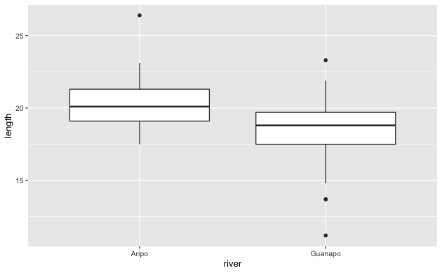

```r
ggplot(rivers,
       aes(x = river, y = length)) +
  geom_boxplot()
```

The box plot does appear to suggest that the two samples have different means, and moreover that the guppies in Guanapo may be smaller than the guppies in Aripo. It isn’t immediately obvious that the two populations don’t have equal variances though (box plots are not quite the right tool for this), so we continue.

### 3, Assumptions

In order to use a Student’s t-test (and for the results to be strictly valid) we have to make three assumptions:

1. The parent distributions from which the samples are taken are both normally distributed (which would lead to the sample data being normally distributed too).
2. Each data point in the samples is independent of the others.
3. The parent distributions should have the same variance.

In this example the first assumption can be ignored as the sample sizes are large enough. If the samples were smaller then we would use histogram, Q-Q plot, and Shapiro-Wilk test as we did in the one-sample data discussion.

The second point we can do nothing about unless we know how the data were collected, so again we ignore it.

The third point regarding equality of variance can be tested using either Bartlett’s test (if the samples are normally distributed) or Levene’s test (if the samples are not normally distributed).

This is where it gets a bit trickier. Although we don’t care if the samples are normally distributed for the t-test to be valid (because the sample size is big enough to compensate), we do need to know if they are normally distributed in order to decide which variance test to use. So we perform Shapiro-Wilk test on both samples separately.

```r
#We can use the filter() function to filter the data by river, then we perform the Shapiro-Wilk test on the length measurement. The shapiro.test() function needs the data in a vector format. We get these by using the pull() function.
rivers %>%
  filter(river == "Aripo") %>%
  pull(length) %>%
  shapiro.test()
```

```
    Shapiro-Wilk normality test

data:  .
W = 0.93596, p-value = 0.02802
```

```r
rivers %>%
  filter(river == "Guanapo") %>%
  pull(length) %>%
  shapiro.test()
```

```
    Shapiro-Wilk normality test

data:  .
W = 0.94938, p-value = 0.1764
```

We can see that whilst the Guanapo data is probably normally distributed (p = 0.1764 > 0.05), the Aripo data is unlikely to be normally distributed (p = 0.02802 < 0.05). Remember that the p-value gives the probability of observing each sample if the parent population is actually normally distributed.

The Shapiro-Wilk test is quite sensitive to sample size. This means that if you have a large sample then even small deviations from normality will cause the sample to fail the test, whereas smaller samples are allowed to pass with much larger deviations. Here the Aripo data has nearly 40 points in it compared with the Guanapo data and so it is much easier for the Aripo sample to fail compared with the Guanapo data.

We can also look at the Q-Q plots for each:

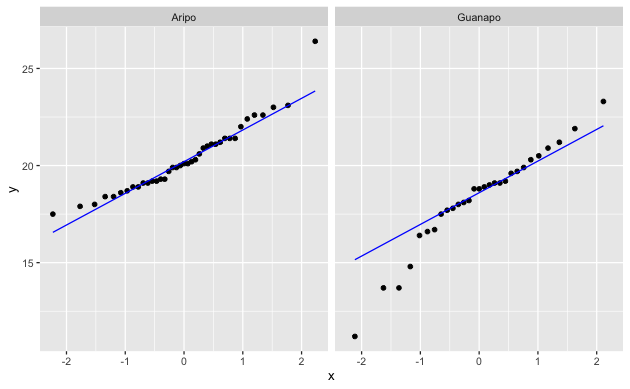

```r
# we group the data by river
# then create a panel per river
# containing the Q-Q plot for that river
ggplot(rivers,
       aes(sample = length)) +
  stat_qq() +
  stat_qq_line(colour = "blue") +
  facet_wrap(facets = vars(river))
```

The Q-Q plots show the opposite of what we found with the Shapiro-Wilk tests: the data for Aripo look pretty normally distributed apart from one data point, whereas the assumption of normality for the Guanapo data is less certain.

What to do? Well, you could be conservative and state that you are not confident that the data in either group are normally distributed. That would be a perfectly reasonable conclusion. I would personally not have issues with stating that the Aripo data are probably normally distributed enough.

#### 3.1 Equality of Variance Assumption

The reason why we’re checking for equality of variance (also referred to as homogeneity of variance) is because many statistical tests assume that the spread of the data within different parental populations (in this case, two) is the same. If that is indeed the case, then the data themselves should have equal spread as well.

##### 3.1.a Non-normality: Levene’s test

The Shapiro-Wilk test and the Q-Q plots have shown that some of the data might not be normal enough (although in opposite directions!) and so we will assume non-normality and in order to test for equality of variance we will use Levene’s test.

he function we use is levene_test() from the rstatix library.

```r
levene_test(data = rivers,
            formula = length ~ river)
```

| df1 | df2 | statistic | p |
| --- | --- | --- | --- |
| 1 | 66 | 1.773184 | 0.1875694 |

The p-value tells us the probability of observing these two samples if they come from distributions with the same variance. As this probability is greater than our arbitrary significance level of 0.05 then we can be somewhat confident that the necessary assumptions for carrying out Student’s t-test on these two samples was valid.

##### 3.1.b Normality: Bartlett’s test

If we had wanted to carry out Bartlett’s test (i.e. if the data had been sufficiently normally distributed) then we would have done:

```r
bartlett.test(length ~ river, data = rivers)
```

```
    Bartlett test of homogeneity of variances

data:  length by river
Bartlett's K-squared = 4.4734, df = 1, p-value = 0.03443
```

### 4. Two-Sample, Two-tailed Student’s t test

In this case we’re ignoring the fact that the data are not normal enough, according to the Shapiro-Wilk test. However, this is not entirely naughty, because the sample sizes are pretty large and the t-test is also pretty robust in this case, we can perform a t-test. Remember, this is only allowed because the variances of the two groups (Aripo and Guanapo) are equal.

```r
t.test(length ~ river,
       alternative = "two.sided",
       var.equal = TRUE,
       data = rivers)
```

```
    Two Sample t-test

data:  length by river
t = 3.8433, df = 66, p-value = 0.0002754
alternative hypothesis: true difference in means between group Aripo and group Guanapo is not equal to 0
95 percent confidence interval:
 0.9774482 3.0909868
sample estimates:
  mean in group Aripo mean in group Guanapo
             20.33077              18.29655
```

The output: The 1st line gives the name of the test and the 2nd line reminds you what the data set was called, and what variables were used. The 3rd line contains the three key outputs from the test: The calculated t-value is 3.8433 There are 66 degrees of freedom The p-value is 0.0002754. The 4th line simply states the alternative hypothesis in terms of the difference between the two sample means (testing if the two sample means are different is equivalent to testing whether the difference in the means is equal to zero). The 5th and 6th lines give the 95th confidence interval. The 7th, 8th and 9th lines give the sample means for each group (20.33077 in Aripo and 18.29655 in Guanapo) which we found earlier.

Again, the p-value is what we’re most interested in. Since the p-value is very small (much smaller than the standard significance level) we choose to say “that it is very unlikely that these two samples came from the same parent distribution and as such we can reject our null hypothesis” and state that: “A Student’s t-test indicated that the mean body length of male guppies in the Guanapo river (mean = 18.29 mm) differs significantly from the mean body length of male guppies in the Aripo river (mean = 20.33 mm, p = 0.0003)”

### 5. Dealing with non-normal data

If we’re not sure that the data we are dealing with may come from a parent distribution that is normal, then we can’t use a Student’s t-test. Instead we use the *Mann-Whitney U test*. This test does not assume that the parent distributions are normally distributed. It does however assume that both have the same shape and variance. With this test we check if the medians of the two parent distributions differ significantly from each other.

Again, we use the rivers data set. We want to test whether the median body length of male guppies differs between samples. We form the following null and alternative hypotheses: $H_0:$ The difference in median body length between the two groups is 0 $(\mu A - \mu G = 0)$ $H_1:$ The difference in median body length between the two groups is not 0 $(\mu A - \mu G \neq 0)$

We use a two-tailed Mann-Whitney U test to see if we can reject the null hypothesis.

#### 5.1. Two-tailed Mann-Whitney U test

Calculate the median for each group (for reference) and perform a two-tailed, Mann-Whitney U test:

```r
#find the medians
rivers %>%
  group_by(river) %>%
  summarize(median_length = median(length))
```

| river | median_length |
| --- | --- |
| Aripo | 20.1 |
| Guanapo | 18.8 |

```r
# perform the Mann-Whitmey U test:
wilcox.test(length ~ river,
            alternative = "two.sided",
            data = rivers)
```

```
Warning: cannot compute exact p-value with ties
```

```
    Wilcoxon rank sum test with continuity correction

data:  length by river
W = 841, p-value = 0.0006464
alternative hypothesis: true location shift is not equal to 0
```

The output: You may get a warning message in the console stating cannot compute exact p-value with ties. This just means that some of the data points have exactly the same value which affects the internal mathematics slightly. However, given that the p-value is so very small, this is not something that we need to worry about.

After the warning message:

The 1st line gives the name of the test and the 2nd line reminds you what the dataset was called, and what variables were used The 3rd line contains the two key outputs from the test: The calculated W-value is 841 (we’ll use this in reporting) The p-value is 0.0006464. The 4th line simply states the alternative hypothesis in terms of the difference between the two sample medians in that if there were a difference then one distribution would be shifted relative to the other.

Given that the p-value is less than 0.05 we can reject the null hypothesis at this confidence level. Again, the p-value on the 3rd line is what we’re most interested in. Since the p-value is very small (much smaller than the standard significance level) we choose to say “that it is very unlikely that these two samples came from the same parent distribution and as such we can reject our null hypothesis”.

### 6. Key Points

Student’s t tests are used when you have two samples of continuous data, which are normally distributed, independent of each other and have equal variance A good way of assessing the assumption of normality is by checking the data against a Q-Q plot We can check equality of variance (homoscedasticity) with Bartlett’s (normal data) or Levene’s (non-normal data) test The Mann-Whitney U test is used when you have two samples of continuous data, which are not normally distributed, but are independent of each other, have equal variance and similar distributional shape